# Rで異常検知 メモ

谷口友哉

先日の大学院の授業で異常検知について学習しました。ここでは、そのときに学んだ内容をRで実装したときのメモを備忘録として残しておきます。このページは以下の参考書の2章と7章の一部をまとめたものです。

- 参考書：入門 機械学習による異常検知 – Rによる実践ガイド –, 井手 剛 著, コロナ社, 2015年

# setup

- ライブラリ読み込み

```r
library(tidyverse)
library(car)
library(MASS)
```

(参考) 外れ値が含むようなデータを生成する方法

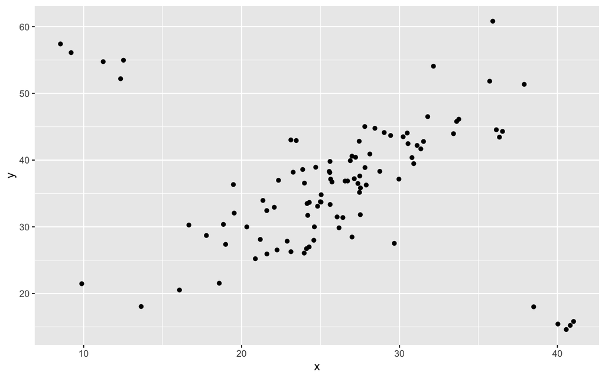

```r
Mu2 <- c(25, 35)                # x,yの平均値
Si2 <- matrix(c(25, 28, 28, 49), ncol=2)    # 相関係数
dat2 <- mvrnorm(90, Mu2, Si2)           # データ生成
Muo1 <- c(10, 55)               # 外れ値の平均値1
Muo2 <- c(40, 15)               # 外れ値の平均値2
Sio <- matrix(c(4, 1, 1, 9), ncol=2)        # 外れ値の分散・共分散
Err1 <- mvrnorm(5, Muo1, Sio)
Err2 <- mvrnorm(5, Muo2, Sio)
Dat <- rbind(dat2, Err1, Err2)
Dat <- data.frame(x = Dat[,1], y = Dat[,2])


ggplot2::ggplot(Dat, aes(x = x ,y = y)) +
  geom_point()
```

# 2章 外れ値検出

- 外れ値検出 (Outlier detection)

```r
?Davis
head(Davis)
```

```
##   sex weight height repwt repht
## 1   M     77    182    77   180
## 2   F     58    161    51   159
## 3   F     53    161    54   158
## 4   M     68    177    70   175
## 5   F     59    157    59   155
## 6   M     76    170    76   165
```

```r
summary(Davis)
```

```
##  sex         weight          height          repwt            repht
##  F:112   Min.   : 39.0   Min.   : 57.0   Min.   : 41.00   Min.   :148.0
##  M: 88   1st Qu.: 55.0   1st Qu.:164.0   1st Qu.: 55.00   1st Qu.:160.5
##          Median : 63.0   Median :169.5   Median : 63.00   Median :168.0
##          Mean   : 65.8   Mean   :170.0   Mean   : 65.62   Mean   :168.5
##          3rd Qu.: 74.0   3rd Qu.:177.2   3rd Qu.: 73.50   3rd Qu.:175.0
##          Max.   :166.0   Max.   :197.0   Max.   :124.00   Max.   :200.0
##                                          NA's   :17       NA's   :17
```

- ヒストグラムと箱ひげ図

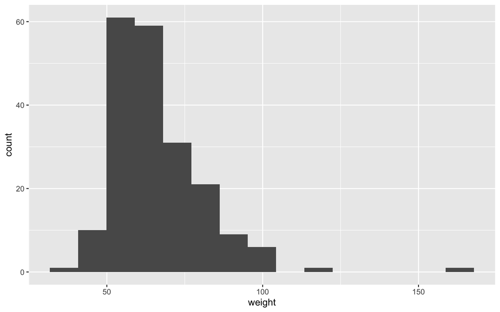

```r
ggplot2::ggplot(Davis, aes(x = weight)) +
  geom_histogram(bins = 15)
```

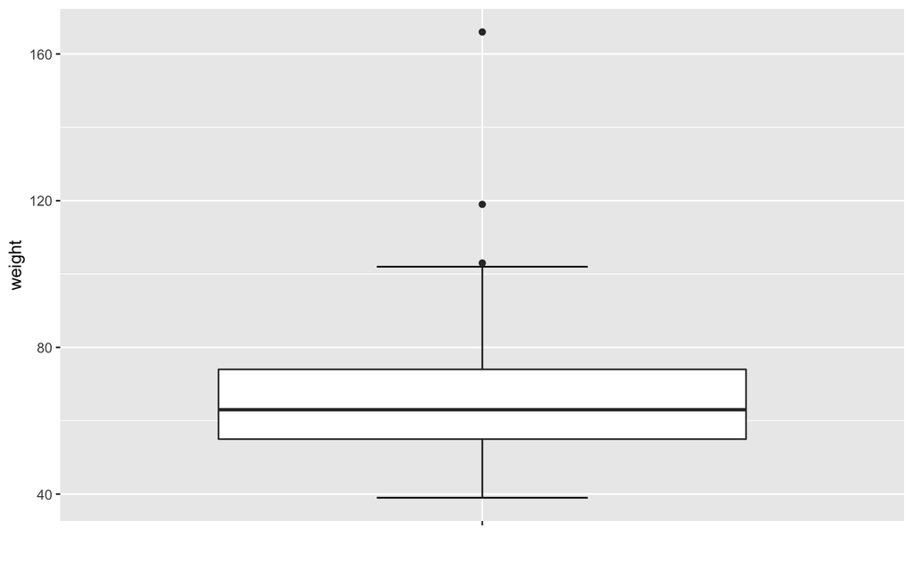

```r
ggplot2::ggplot(Davis, aes(x = "", y = weight)) +
  stat_boxplot(geom = "errorbar", width = 0.3) +   # ひげと横線を描写するコード
  geom_boxplot() +
  labs(x = "")
```

- 正規分布を重ねる
  - https://stackoverflow.com/questions/27661852/adding-a-density-line-to-a-histogram-with-count-data-in-ggplot2

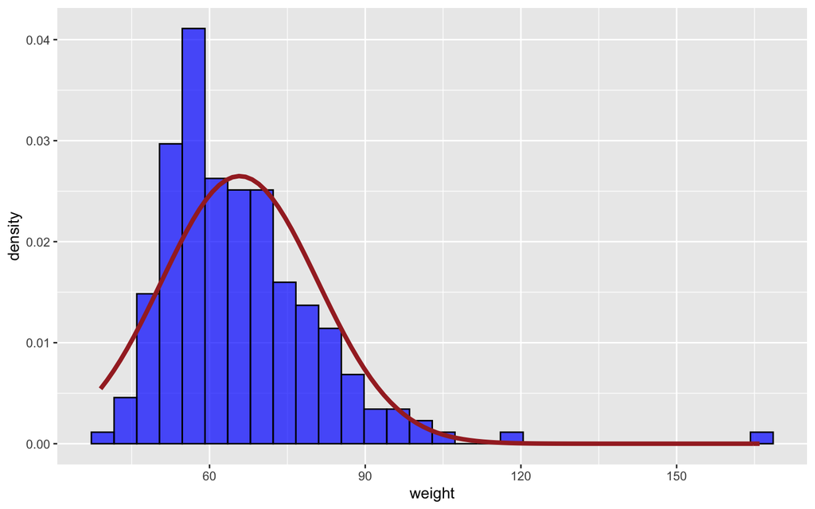

```r
# 正規分布を重ねる
ggplot2::ggplot(Davis, aes(x = weight)) +
  geom_histogram(aes(y=..density..),colour = "black", fill = "blue", alpha = 0.7) +
  stat_function(fun = dnorm, args = fitdistr(Davis$weight,"normal")$estimate,size = 1.5,colour = "brown")
```

- hotelling

```r
mu <- mean(Davis$weight)
s2 <- mean((Davis$weight - mu)^2)

sd <- sqrt(s2)
c(mu, s2)
```

```
## [1]  65.80 226.72
```

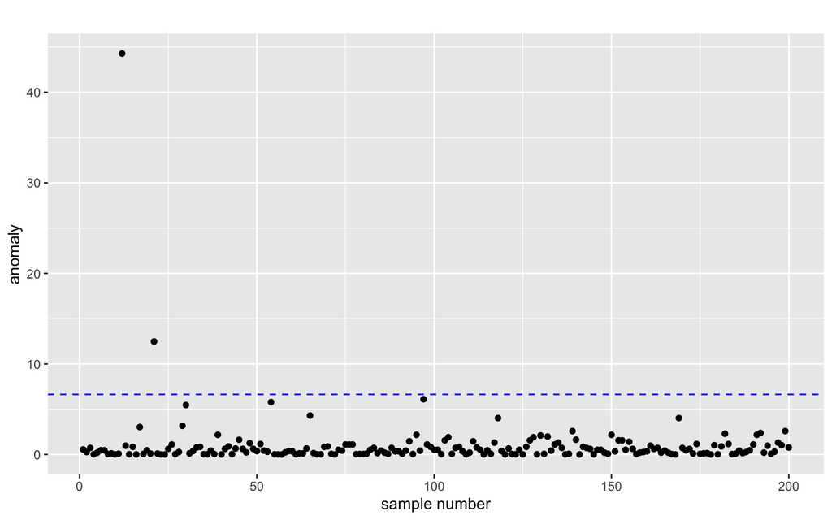

```r
a <- (Davis$weight - mu)^2/s2 # 異常度
th <-  qchisq(0.99, 1) # 閾値

d <- data.frame(a)


ggplot2::ggplot(d,aes(x=c(1:200),y=a)) +
  geom_point() +
  geom_hline(yintercept = th, linetype = "dashed", colour = "blue") +
  labs(title = "", x = "sample number", y = "anomaly")
```

# 7章 異常部位検知と変化点検知

- Keogh et al. (2005) の心電図データを以下から取得
  - http://www.cs.ucr.edu/~eamonn/discords/qtdbsel102.txt

```r
dt <- read.table("qtdbsel102.txt")
head(dt)
```

```
##        V1    V2    V3
## 1 200.000 4.770 2.100
## 2 200.004 4.820 2.135
## 3 200.008 4.805 2.190
## 4 200.012 4.750 2.285
## 5 200.016 4.710 2.440
## 6 200.020 4.695 2.620
```

- データを分割, 可視化する

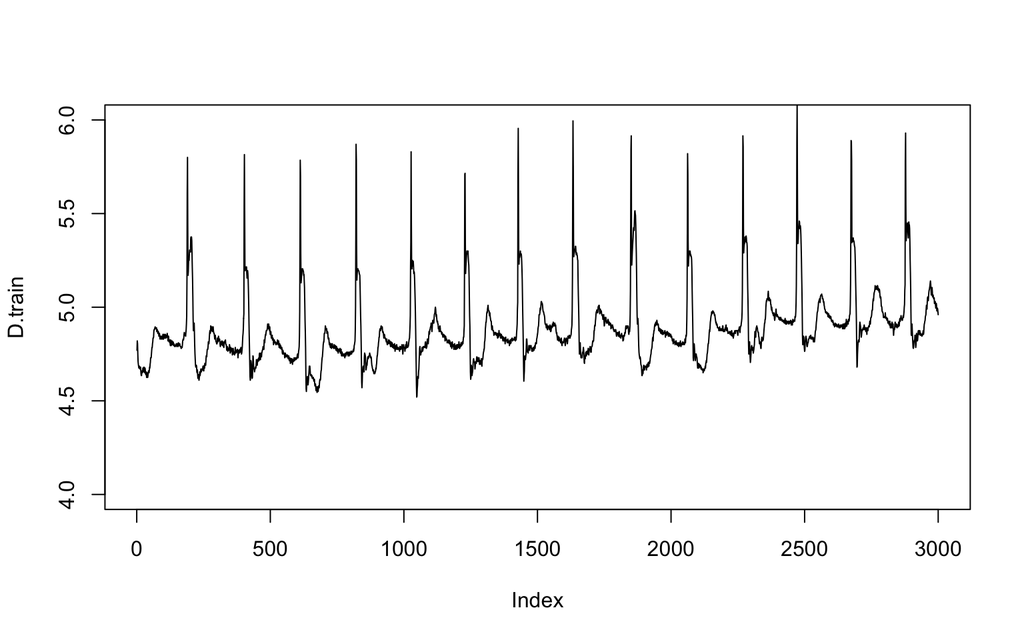

```r
D.train <- dt[1:3000,2] #訓練データ
D.test <- dt[3001:6000,2] #検証データ
plot(D.train, type="l", ylim=c(4.0,6.0)) #訓練データの図示
```

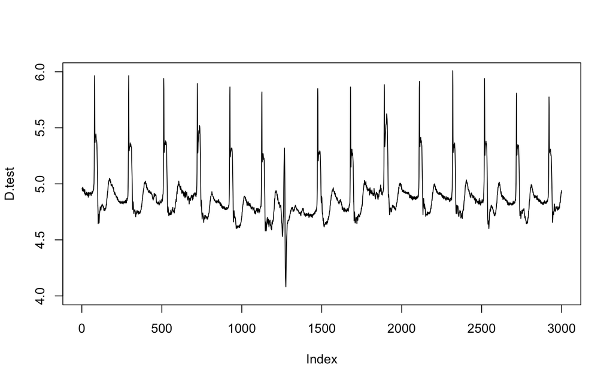

```r
plot(D.test, type="l", ylim=c(4.0,6.0)) #検証データの図示
```

## 最近傍までの距離で異常部位検知 (Discord discovery)

- knnのためにFNNパッケージを読み込んでおく

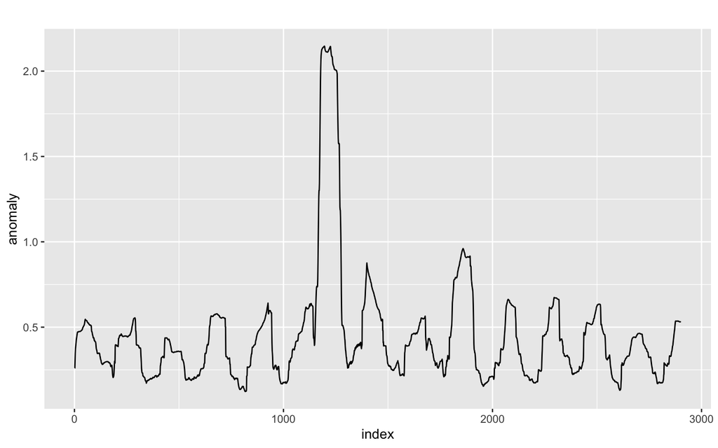

```r
library(FNN) # knn

width <- 100
nk <- 1

D.train <- embed(dt[1:3000, 2], width)
D.test <- embed(dt[3001:6000, 2], width)


d <- FNN::knnx.dist(D.train, D.test, k = nk) # knn

df <- data.frame(x = c(1:(3000 - width + 1)), y = d[,1])

p <- ggplot2::ggplot(df,aes(x = x,y = y)) +
  geom_line() +
  labs(title = "", x = "index", y = "anomaly")

plot(p)
```

## 変化点検知 (Change-point detection)

- 特異スペクトル変換法で計算した変化度による変化点検知

```r
# 特異スペクトル変換
xi <- dt[3001:6000, 2]
w <- 50 # width
m <- 2
k <- w/2
L <- k/2 # lag
Tt <- length(xi)
score <- rep(0, Tt)

for(t in (w+k):(Tt-L+1)) {
  t.start <- t-w-k+1
  t.end <- t-1
  X1 <- t(embed(xi[t.start:t.end], w))[w:1,] # trajectory matrix
  X2 <- t(embed(xi[(t.start + L):(t.end + L)], w))[w:1,] # test matrix

  U1 <- svd(X1)$u[,1:m] # X11 SVD
  U2 <- svd(X2)$u[,1:m] # X12 SVD
  sig1 <- svd(t(U1) %*% U2)$d[1] # overlap
  score[t] <- 1 - sig1^2 # change score
}

df <- data.frame(x = c(1:3000), y = score)
head(df)
```

```
##   x y
## 1 1 0
## 2 2 0
## 3 3 0
## 4 4 0
## 5 5 0
## 6 6 0
```

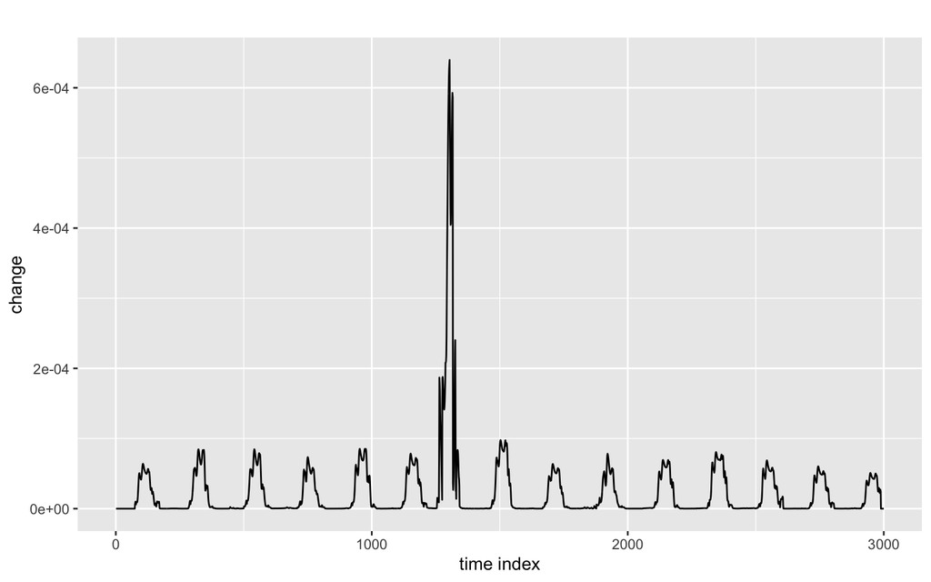

```r
p <- ggplot2::ggplot(df,aes(x = x,y = y)) +
  geom_line() +
  labs(title = "", x = "time index", y = "change")

plot(p)
```

異常部位検出よりも明瞭に変化点が検出されている

# まとめ

外れ値検出、異常部位検出、変化点検知について簡単に触ってみました。  
今回の内容を元に、異常検知について (ざっくり) 俯瞰した note を後日またアップします。